# Ejercicio de Precio de Casas

## INTRODUCCIÓN

El siguiente trabajo es sobre un ejercicio que se encuentra en Kaggle sobre la estimación del precio de las casas en Ames, Iowa, basado en diferentes variables con la finalidad de poner en práctica lo aprendido en el Módulo de Machine Learning [Ver-Kaggle](https://www.kaggle.com/c/house-prices-advanced-regression-techniques).

## DIMENSIONAMIENTO DE LAS BASES

La base de datos de desarrollo “train” tiene la siguiente dimension:

```r
train <- as.data.frame(read.csv("train.csv",header=TRUE))

print(paste0("Número de renglones ",nrow(train)))
```

```
## [1] "Número de renglones 1460"
```

```r
print(paste0("Número de columnas ",ncol(train)))
```

```
## [1] "Número de columnas 81"
```

La base de datos de validación “test” tiene la siguiente dimensión:

```r
test <- as.data.frame(read.csv("test.csv",header=TRUE))

print(paste0("Número de renglones ",nrow(test)))
```

```
## [1] "Número de renglones 1459"
```

```r
print(paste0("Número de columnas ",ncol(test)))
```

```
## [1] "Número de columnas 80"
```

Podemos ver que la base de datos “test” tiene 1 columna menos que la base “train”. Esto se debe a las condiciones que Kaggle esteblece para este proyecto: El output de la base de validación no se proveerá, se tiene que enviar el modelo a Kaggle para que regrese el performance del mismo y Kaggle enviará el score final.

## DESCRIPCIÓN DE VARIABLES

A continuación veremos cuáles son las variables con las que cuenta nuestra base de datos de desarrollo:

```r
library(knitr)
library(readxl)
library(dbplyr)
```

```r
library(magrittr)
library(corrplot)
vars<-read.csv("vars.csv", header=TRUE, sep=",", fileEncoding = "utf8")

desc<-data.frame(Variables = names(train),
           Descripcion=vars[,2],
           Clase = sapply(train, class),
           Valores_Posibles= sapply(train, function(x) paste0(head(x),  collapse = ", ")),
           row.names = NULL)
kable(desc)
```

| Variables | Descripcion | Clase | Valores_Posibles |
| --- | --- | --- | --- |
| Id | ID | integer | 1, 2, 3, 4, 5, 6 |
| MSSubClass | La clase de construccion | integer | 60, 20, 60, 70, 60, 50 |
| MSZoning | La clasificacion general de zonificacion | factor | RL, RL, RL, RL, RL, RL |
| LotFrontage | Pies lineales de calle conectados a la propiedad | integer | 65, 80, 68, 60, 84, 85 |
| LotArea | Tamano del lote en pies cuadrados | integer | 8450, 9600, 11250, 9550, 14260, 14115 |
| Street | Tipo de acceso por carretera | factor | Pave, Pave, Pave, Pave, Pave, Pave |
| Alley | Tipo de acceso al callejon | factor | NA, NA, NA, NA, NA, NA |
| LotShape | Forma general de propiedad | factor | Reg, Reg, IR1, IR1, IR1, IR1 |
| LandContour | Planitud de la propiedad | factor | Lvl, Lvl, Lvl, Lvl, Lvl, Lvl |
| Utilities | Tipo de utilidades disponibles | factor | AllPub, AllPub, AllPub, AllPub, AllPub, AllPub |
| LotConfig | Configuracion de lote | factor | Inside, FR2, Inside, Corner, FR2, Inside |
| LandSlope | Pendiente de propiedad | factor | Gtl, Gtl, Gtl, Gtl, Gtl, Gtl |
| Neighborhood | Ubicaciones fisicas dentro de los limites de la ciudad de Ames | factor | CollgCr, Veenker, CollgCr, Crawfor, NoRidge, Mitchel |
| Condition1 | Proximidad a la carretera principal o ferrocarril | factor | Norm, Feedr, Norm, Norm, Norm, Norm |
| Condition2 | Proximidad a la carretera principal o al ferrocarril (si hay un segundo presente) | factor | Norm, Norm, Norm, Norm, Norm, Norm |
| BldgType | Tipo de vivienda | factor | 1Fam, 1Fam, 1Fam, 1Fam, 1Fam, 1Fam |
| HouseStyle | Estilo de vivienda | factor | 2Story, 1Story, 2Story, 2Story, 2Story, 1.5Fin |
| OverallQual | Material general y calidad de acabado | integer | 7, 6, 7, 7, 8, 5 |
| OverallCond | Calificacion general de la condicion | integer | 5, 8, 5, 5, 5, 5 |
| YearBuilt | Fecha de construccion original | integer | 2003, 1976, 2001, 1915, 2000, 1993 |
| YearRemodAdd | Remodelacion fecha | integer | 2003, 1976, 2002, 1970, 2000, 1995 |
| RoofStyle | Tipo de techo | factor | Gable, Gable, Gable, Gable, Gable, Gable |
| RoofMatl | Material del techo | factor | CompShg, CompShg, CompShg, CompShg, CompShg, CompShg |
| Exterior1st | Revestimiento exterior de la casa | factor | VinylSd, MetalSd, VinylSd, Wd Sdng, VinylSd, VinylSd |
| Exterior2nd | Revestimiento exterior en la casa (si hay mas de un material) | factor | VinylSd, MetalSd, VinylSd, Wd Shng, VinylSd, VinylSd |
| MasVnrType | Tipo de chapa de mamposteria | factor | BrkFace, None, BrkFace, None, BrkFace, None |
| MasVnrArea | Area de chapa de mamposteria en pies cuadrados | integer | 196, 0, 162, 0, 350, 0 |
| ExterQual | Calidad del material exterior | factor | Gd, TA, Gd, TA, Gd, TA |
| ExterCond | Condicion actual del material en el exterior | factor | TA, TA, TA, TA, TA, TA |
| Foundation | Tipo de fundacion | factor | PConc, CBlock, PConc, BrkTil, PConc, Wood |

[output cut: 51 more lines]

Podemos ver que hay varias variables que R lee como entero cuando en realidad son factor. Procederemos a hacer el cambio de nivel de dichas variables.

```r
train[,'Id']<-as.factor(train[,'Id'])
train[,'MSSubClass']<-as.factor(train[,'MSSubClass'])
train[,'OverallQual']<-as.factor(train[,'OverallQual'])
train[,'OverallCond']<-as.factor(train[,'OverallCond'])
train[,'YearBuilt']<-as.factor(train[,'YearBuilt'])
train[,'YearRemodAdd']<-as.factor(train[,'YearRemodAdd'])
train[,'GarageYrBlt']<-as.factor(train[,'GarageYrBlt'])
train[,'MoSold']<-as.factor(train[,'MoSold'])
train[,'YrSold']<-as.factor(train[,'YrSold'])

desc2<-data.frame(Variables = names(train),
           Descripcion=vars[,2],
           Clase = sapply(train, class),
           Valores_Posibles= sapply(train, function(x) paste0(head(x),  collapse = ", ")),
           row.names = NULL)
kable(desc2)
```

| Variables | Descripcion | Clase | Valores_Posibles |
| --- | --- | --- | --- |
| Id | ID | factor | 1, 2, 3, 4, 5, 6 |
| MSSubClass | La clase de construccion | factor | 60, 20, 60, 70, 60, 50 |
| MSZoning | La clasificacion general de zonificacion | factor | RL, RL, RL, RL, RL, RL |
| LotFrontage | Pies lineales de calle conectados a la propiedad | integer | 65, 80, 68, 60, 84, 85 |
| LotArea | Tamano del lote en pies cuadrados | integer | 8450, 9600, 11250, 9550, 14260, 14115 |
| Street | Tipo de acceso por carretera | factor | Pave, Pave, Pave, Pave, Pave, Pave |
| Alley | Tipo de acceso al callejon | factor | NA, NA, NA, NA, NA, NA |
| LotShape | Forma general de propiedad | factor | Reg, Reg, IR1, IR1, IR1, IR1 |
| LandContour | Planitud de la propiedad | factor | Lvl, Lvl, Lvl, Lvl, Lvl, Lvl |
| Utilities | Tipo de utilidades disponibles | factor | AllPub, AllPub, AllPub, AllPub, AllPub, AllPub |
| LotConfig | Configuracion de lote | factor | Inside, FR2, Inside, Corner, FR2, Inside |
| LandSlope | Pendiente de propiedad | factor | Gtl, Gtl, Gtl, Gtl, Gtl, Gtl |
| Neighborhood | Ubicaciones fisicas dentro de los limites de la ciudad de Ames | factor | CollgCr, Veenker, CollgCr, Crawfor, NoRidge, Mitchel |
| Condition1 | Proximidad a la carretera principal o ferrocarril | factor | Norm, Feedr, Norm, Norm, Norm, Norm |
| Condition2 | Proximidad a la carretera principal o al ferrocarril (si hay un segundo presente) | factor | Norm, Norm, Norm, Norm, Norm, Norm |
| BldgType | Tipo de vivienda | factor | 1Fam, 1Fam, 1Fam, 1Fam, 1Fam, 1Fam |
| HouseStyle | Estilo de vivienda | factor | 2Story, 1Story, 2Story, 2Story, 2Story, 1.5Fin |
| OverallQual | Material general y calidad de acabado | factor | 7, 6, 7, 7, 8, 5 |
| OverallCond | Calificacion general de la condicion | factor | 5, 8, 5, 5, 5, 5 |
| YearBuilt | Fecha de construccion original | factor | 2003, 1976, 2001, 1915, 2000, 1993 |
| YearRemodAdd | Remodelacion fecha | factor | 2003, 1976, 2002, 1970, 2000, 1995 |
| RoofStyle | Tipo de techo | factor | Gable, Gable, Gable, Gable, Gable, Gable |
| RoofMatl | Material del techo | factor | CompShg, CompShg, CompShg, CompShg, CompShg, CompShg |
| Exterior1st | Revestimiento exterior de la casa | factor | VinylSd, MetalSd, VinylSd, Wd Sdng, VinylSd, VinylSd |
| Exterior2nd | Revestimiento exterior en la casa (si hay mas de un material) | factor | VinylSd, MetalSd, VinylSd, Wd Shng, VinylSd, VinylSd |
| MasVnrType | Tipo de chapa de mamposteria | factor | BrkFace, None, BrkFace, None, BrkFace, None |
| MasVnrArea | Area de chapa de mamposteria en pies cuadrados | integer | 196, 0, 162, 0, 350, 0 |
| ExterQual | Calidad del material exterior | factor | Gd, TA, Gd, TA, Gd, TA |
| ExterCond | Condicion actual del material en el exterior | factor | TA, TA, TA, TA, TA, TA |
| Foundation | Tipo de fundacion | factor | PConc, CBlock, PConc, BrkTil, PConc, Wood |

[output cut: 52 more lines]

```r
var_num <- c("LotFrontage","LotArea","MasVnrArea","BsmtFinSF1","BsmtFinSF2","BsmtUnfSF","TotalBsmtSF","X1stFlrSF","X2ndFlrSF","LowQualFinSF","GrLivArea","BsmtFullBath","BsmtHalfBath","FullBath","HalfBath","BedroomAbvGr","KitchenAbvGr","TotRmsAbvGrd","Fireplaces","GarageCars","GarageArea","WoodDeckSF","OpenPorchSF","EnclosedPorch","X3SsnPorch","ScreenPorch","PoolArea","MiscVal")
```

## ESTADÍSTICOS DE SUMARIZACIÓN

A continuación veremos estadísticos básicos de sumarización de nuestra base de desarrollo “train”:

```r
summary(train)
```

```
##        Id         MSSubClass     MSZoning     LotFrontage
##  1      :   1   20     :536   C (all):  10   Min.   : 21.00
##  2      :   1   60     :299   FV     :  65   1st Qu.: 59.00
##  3      :   1   50     :144   RH     :  16   Median : 69.00
##  4      :   1   120    : 87   RL     :1151   Mean   : 70.05
##  5      :   1   30     : 69   RM     : 218   3rd Qu.: 80.00
##  6      :   1   160    : 63                  Max.   :313.00
##  (Other):1454   (Other):262                  NA's   :259
##     LotArea        Street      Alley      LotShape  LandContour
##  Min.   :  1300   Grvl:   6   Grvl:  50   IR1:484   Bnk:  63
##  1st Qu.:  7554   Pave:1454   Pave:  41   IR2: 41   HLS:  50
##  Median :  9478               NA's:1369   IR3: 10   Low:  36
##  Mean   : 10517                           Reg:925   Lvl:1311
##  3rd Qu.: 11602
##  Max.   :215245
##
##   Utilities      LotConfig    LandSlope   Neighborhood   Condition1
##  AllPub:1459   Corner : 263   Gtl:1382   NAmes  :225   Norm   :1260
##  NoSeWa:   1   CulDSac:  94   Mod:  65   CollgCr:150   Feedr  :  81
##                FR2    :  47   Sev:  13   OldTown:113   Artery :  48
##                FR3    :   4              Edwards:100   RRAn   :  26
##                Inside :1052              Somerst: 86   PosN   :  19
##                                          Gilbert: 79   RRAe   :  11
##                                          (Other):707   (Other):  15
##    Condition2     BldgType      HouseStyle   OverallQual   OverallCond
##  Norm   :1445   1Fam  :1220   1Story :726   5      :397   5      :821
##  Feedr  :   6   2fmCon:  31   2Story :445   6      :374   6      :252
##  Artery :   2   Duplex:  52   1.5Fin :154   7      :319   7      :205
##  PosN   :   2   Twnhs :  43   SLvl   : 65   8      :168   8      : 72
##  RRNn   :   2   TwnhsE: 114   SFoyer : 37   4      :116   4      : 57
##  PosA   :   1                 1.5Unf : 14   9      : 43   3      : 25
##  (Other):   2                 (Other): 19   (Other): 43   (Other): 28
##    YearBuilt     YearRemodAdd   RoofStyle       RoofMatl     Exterior1st
##  2006   :  67   1950   :178   Flat   :  13   CompShg:1434   VinylSd:515
##  2005   :  64   2006   : 97   Gable  :1141   Tar&Grv:  11   HdBoard:222
##  2004   :  54   2007   : 76   Gambrel:  11   WdShngl:   6   MetalSd:220
##  2007   :  49   2005   : 73   Hip    : 286   WdShake:   5   Wd Sdng:206
##  2003   :  45   2004   : 62   Mansard:   7   ClyTile:   1   Plywood:108
##  1976   :  33   2000   : 55   Shed   :   2   Membran:   1   CemntBd: 61
##  (Other):1148   (Other):919                  (Other):   2   (Other):128
```

[output cut: 89 more lines]

```
##  Min.   :    0.00   6      :253   2006:314   WD     :1267   Abnorml: 101
##  1st Qu.:    0.00   7      :234   2007:329   New    : 122   AdjLand:   4
##  Median :    0.00   5      :204   2008:304   COD    :  43   Alloca :  12
##  Mean   :   43.49   4      :141   2009:338   ConLD  :   9   Family :  20
##  3rd Qu.:    0.00   8      :122   2010:175   ConLI  :   5   Normal :1198
##  Max.   :15500.00   3      :106              ConLw  :   5   Partial: 125
##                     (Other):400              (Other):   9
##    SalePrice
##  Min.   : 34900
##  1st Qu.:129975
##  Median :163000
##  Mean   :180921
##  3rd Qu.:214000
##  Max.   :755000
##
```

Se observa lo siguiente:

- Hay algunas variables que contienen muchos valores nulos (ej. “PoolQC”, “Fence”, “MiscFeature”..)
- Hay algunas variables categóricas que agrupan la mayoría de los registros en una sola categoría (ej. “Street”, “Condition2”..), hay alta probabilidad de que éstas variables no sean significativas cuando se apliquen los modelos de regresión.

## VALORES AUSENTES

A continuación se analizará a detalle el porcentaje de valores ausentes en cada variable:

```r
library(tidyverse)
```

```r
map(train, ~sum(is.na(.))/nrow(train)*100)
```

```
## $Id
## [1] 0
##
## $MSSubClass
## [1] 0
##
## $MSZoning
## [1] 0
##
## $LotFrontage
## [1] 17.73973
##
## $LotArea
## [1] 0
##
## $Street
## [1] 0
##
## $Alley
## [1] 93.76712
##
## $LotShape
## [1] 0
##
## $LandContour
## [1] 0
##
## $Utilities
## [1] 0
##
## $LotConfig
## [1] 0
##
## $LandSlope
## [1] 0
##
## $Neighborhood
## [1] 0
##
## $Condition1
```

[output cut: 187 more lines]

```
##
## $MoSold
## [1] 0
##
## $YrSold
## [1] 0
##
## $SaleType
## [1] 0
##
## $SaleCondition
## [1] 0
##
## $SalePrice
## [1] 0
```

Se observa que la variable “Alley” tiene 93% de valores ausentes, la variable “Fence” un 80%, “MiscFeature” 96%, “PoolQC” un 99% y “FireplaceQu” un 47% por lo que serán excluidas del análisis.

```r
train <- train[,!colnames(train)=="Alley"]
train <- train[,!colnames(train)=="Fence"]
train <- train[,!colnames(train)=="MiscFeature"]
train <- train[,!colnames(train)=="PoolQC"]
train <- train[,!colnames(train)=="FireplaceQu"]
```

```r
train_miss <- na.omit(train)
```

1. Verificar si en los registros donde no existen valores ausentes, las variables numéricas tienen correlación con otras.

```r
train_miss_num <- train_miss[,var_num]
correlacion<-round(cor(train_miss_num),1)
```

La variable “LotFrontage” que es la que presenta más valores ausentes (18% de los registros) debería estar poblada ya que indica el total de Pies lineales de calle conectados a la propiedad por lo que se tratará de estimar mediante imputación. Se observa que ésta variable presenta una correlación de 0.5 con la variable “X1stFlrSF” que indica el total de Pies Cuadrados del primer piso por lo que se utilizará ésta segunda variable para estimar el valor de la primera.

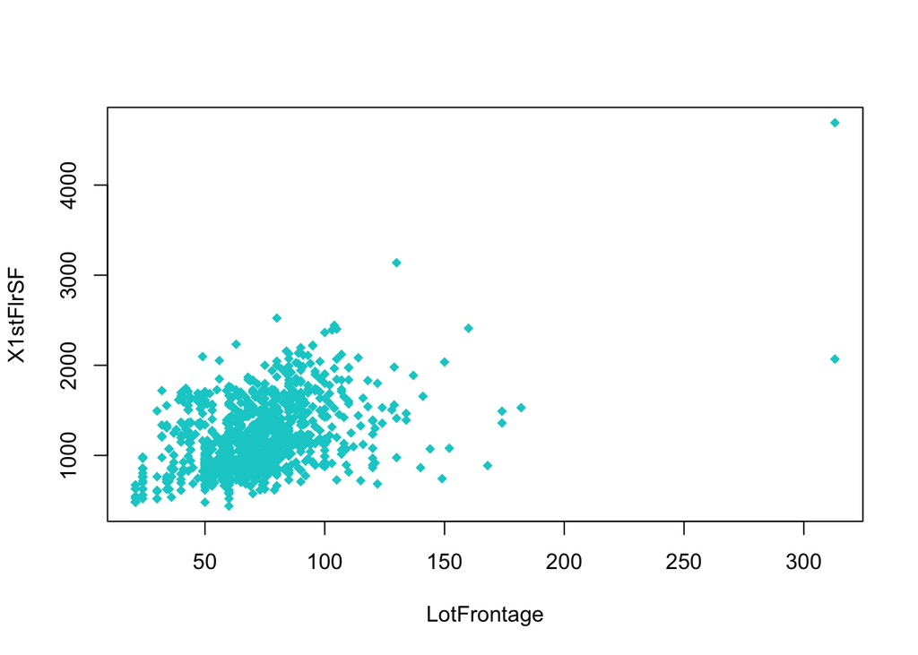

```r
#Gráfica de Correlación de "LotFrontage" y "1stFlrSF"
plot(train_miss$LotFrontage, train_miss$X1stFlrSF, xlab="LotFrontage", ylab="X1stFlrSF", pch=18, col="cyan3")
```

Se asignará el promedio de Y para cada valor de X ausente..

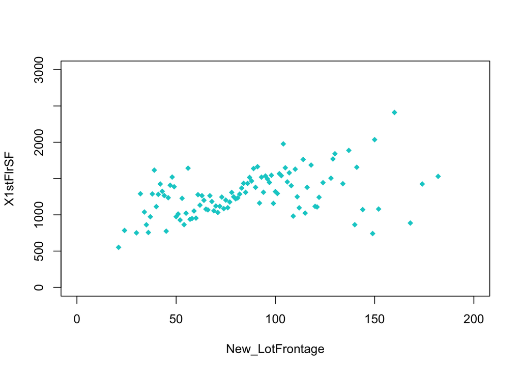

```r
LF_new <- train_miss %>%
  group_by(LotFrontage) %>%
  summarize(mean(X1stFlrSF))

colnames(LF_new)[colnames(LF_new)=="mean(X1stFlrSF)"] <- "X1stFlrSF"
colnames(LF_new)[colnames(LF_new)=="LotFrontage"] <- "New_LotFrontage"

# Nueva gráfica de Correlación de "LotFrontage" y "1stFlrSF"
plot(LF_new$New_LotFrontage, LF_new$X1stFlrSF, xlab="New_LotFrontage", ylab="X1stFlrSF", xlim=c(0,200), ylim=c(0,3000), pch=18, col="cyan3")
```

```r
train_a <- merge(x = train, y = LF_new, by = "X1stFlrSF", all.x = TRUE)
train_a$LotFrontage = ifelse(is.na(train_a$LotFrontage), train_a$New_LotFrontage, train_a$LotFrontage)
```

Se verifican los valores faltantes con esta corrección..

```r
train_a <- train_a[,!colnames(train_a)=="Alley"]
train_a <- train_a[,!colnames(train_a)=="Fence"]
train_a <- train_a[,!colnames(train_a)=="MiscFeature"]
train_a <- train_a[,!colnames(train_a)=="PoolQC"]
train_a <- train_a[,!colnames(train_a)=="FireplaceQu"]
train_a <- train_a[,!colnames(train_a)=="New_LotFrontage"]

train_miss_new <- na.omit(train_a)
```

Debido a que el procedimiento anterior no corrigió los valores ausentes y siguen faltando al rededor del 25% de los valores, se procederá a eliminar la variable.

```r
train <- train[,!colnames(train)=="LotFrontage"]
```

## NIVELES DE LAS VARIABLES - FACTOR

```r
train <- train[,!colnames(train)=="Street"]
train <- train[,!colnames(train)=="Utilities"]
train <- train[,!colnames(train)=="Condition2"]
train <- train[,!colnames(train)=="RoofMatl"]
train <- train[,!colnames(train)=="OverallCond"]
train <- train[,!colnames(train)=="OverallQual"]
train <- train[,!colnames(train)=="Exterior1st"]
train <- train[,!colnames(train)=="ExterCond"]
train <- train[,!colnames(train)=="Heating"]
```

Posteriormente se eliminarán todos los registros con valores faltantes en las siguientes variables: “GarageType” 5.5%, “GarageYrBlt” 5.5%, “GarageFinish” 5.5%, “GarageQual” 5.5%, “GarageCond” 5.5%, “BsmtExposure” 2.6%, “BsmtFinType2” 2.6%, “BsmtQual” 2.5%, “BsmtCond” 2.5%, “BsmtFinType1” 2.5%, “MasVnrType” 0.5%, “MasVnrArea” 0.5%, “Electrical” 0.1%.

```r
train_miss <- na.omit(train)
```

Con lo anterior logramos quedarnos con 1,338 registros (92% de las observaciones) para el desarrollo del modelo.

## CREACIÓN DE MUESTRAS

Debido a la ausencia de variable objetivo en la base de validación “test”, haremos una partición de la base “train” en 2: train2 y test2, como se muestra a continuación:

```r
set.seed(123)
library(gtools)
#match(train$MSZoning,unique(mixedsort(train$MSZoning)))
#train$MSZoning2 <-as.numeric(factor(train$MSZoning, #levels=unique(mixedsort(train$MSZoning))))

smp_size <- floor(0.75 * nrow(train_miss))
train_ind <- sample(seq_len(nrow(train_miss)), size = smp_size)

train_smp <- train_miss[train_ind, ]
test_smp <- train_miss[-train_ind, ]
```

## ANÁLISIS DE REGRESIÓN LINEAL MÚLTIPLE

Ahora procederemos a hacer un análisis de regresión lineal múltiple, donde nuestra variable objetivo será “SalePrice”.

1. MODELO 1. La primera corrida del modelo considerará los ajustes realizados en la sección anterior:

```r
library(ISLR)
library(ggplot2)
library(MASS)
library(DAAG)
baseline <- lm(SalePrice ~ MSSubClass+  MSZoning+   LotArea+        LotShape+   LandContour+    LotConfig+  LandSlope+  Neighborhood+   Condition1+ BldgType+   HouseStyle+ YearBuilt+  YearRemodAdd+   RoofStyle+      Exterior2nd+    MasVnrType+ MasVnrArea+ ExterQual+  Foundation+ BsmtQual+   BsmtCond+   BsmtExposure+   BsmtFinType1+   BsmtFinSF1+ BsmtFinType2+   BsmtFinSF2+ BsmtUnfSF+  TotalBsmtSF+    HeatingQC+  CentralAir+ Electrical+ X1stFlrSF+  X2ndFlrSF+  LowQualFinSF+   GrLivArea+  BsmtFullBath+   BsmtHalfBath+   FullBath+   HalfBath+   BedroomAbvGr+   KitchenAbvGr+   KitchenQual+    TotRmsAbvGrd+   Functional+ Fireplaces+ GarageType+ GarageYrBlt+    GarageFinish+   GarageCars+ GarageArea+ GarageQual+ GarageCond+ PavedDrive+ WoodDeckSF+ OpenPorchSF+    EnclosedPorch+  X3SsnPorch+ ScreenPorch+    PoolArea+   MiscVal+    MoSold+ YrSold+ SaleType+   SaleCondition
, data=train_smp)


print(summary(baseline))
```

```
##
## Call:
## lm(formula = SalePrice ~ MSSubClass + MSZoning + LotArea + LotShape +
##     LandContour + LotConfig + LandSlope + Neighborhood + Condition1 +
##     BldgType + HouseStyle + YearBuilt + YearRemodAdd + RoofStyle +
##     Exterior2nd + MasVnrType + MasVnrArea + ExterQual + Foundation +
##     BsmtQual + BsmtCond + BsmtExposure + BsmtFinType1 + BsmtFinSF1 +
##     BsmtFinType2 + BsmtFinSF2 + BsmtUnfSF + TotalBsmtSF + HeatingQC +
##     CentralAir + Electrical + X1stFlrSF + X2ndFlrSF + LowQualFinSF +
##     GrLivArea + BsmtFullBath + BsmtHalfBath + FullBath + HalfBath +
##     BedroomAbvGr + KitchenAbvGr + KitchenQual + TotRmsAbvGrd +
##     Functional + Fireplaces + GarageType + GarageYrBlt + GarageFinish +
##     GarageCars + GarageArea + GarageQual + GarageCond + PavedDrive +
##     WoodDeckSF + OpenPorchSF + EnclosedPorch + X3SsnPorch + ScreenPorch +
##     PoolArea + MiscVal + MoSold + YrSold + SaleType + SaleCondition,
##     data = train_smp)
##
## Residuals:
##     Min      1Q  Median      3Q     Max
## -176161  -11177       0   10119  201739
##
## Coefficients: (12 not defined because of singularities)
##                        Estimate Std. Error t value Pr(>|t|)
## (Intercept)           9.305e+04  1.063e+05   0.876 0.381567
## MSSubClass30         -1.455e+04  1.570e+04  -0.927 0.354476
## MSSubClass40         -2.053e+04  4.712e+04  -0.436 0.663294
## MSSubClass45         -3.596e+04  4.509e+04  -0.798 0.425480
## MSSubClass50          3.648e+04  2.533e+04   1.440 0.150395
## MSSubClass60         -6.841e+03  2.042e+04  -0.335 0.737791
## MSSubClass70          1.642e+03  2.356e+04   0.070 0.944474
## MSSubClass75         -1.331e+05  6.838e+04  -1.946 0.052108 .
## MSSubClass80          2.021e+04  2.820e+04   0.716 0.474002
## MSSubClass85          1.490e+04  2.538e+04   0.587 0.557326
## MSSubClass90         -6.120e+02  2.493e+04  -0.025 0.980428
## MSSubClass120        -1.374e+04  2.481e+04  -0.554 0.579852
## MSSubClass160        -2.246e+04  3.370e+04  -0.667 0.505321
## MSSubClass180         7.969e+03  3.699e+04   0.215 0.829538
## MSSubClass190        -2.326e+05  8.248e+04  -2.820 0.004978 **
## MSZoningFV            6.818e+04  3.155e+04   2.161 0.031146 *
## MSZoningRH            5.411e+04  3.547e+04   1.526 0.127680
```

[output cut: 441 more lines]

```
## SaleTypeConLw        -9.753e+03  2.746e+04  -0.355 0.722597
## SaleTypeCWD           6.389e+04  3.122e+04   2.047 0.041169 *
## SaleTypeNew           5.325e+04  3.305e+04   1.611 0.107746
## SaleTypeWD            4.446e+03  8.137e+03   0.546 0.585051
## SaleConditionAdjLand  2.839e+04  4.380e+04   0.648 0.517092
## SaleConditionAlloca   4.191e+04  3.083e+04   1.359 0.174660
## SaleConditionFamily  -3.841e+03  1.253e+04  -0.307 0.759316
## SaleConditionNormal   5.898e+03  6.148e+03   0.959 0.337758
## SaleConditionPartial -3.794e+04  3.146e+04  -1.206 0.228244
## ---
## Signif. codes:  0 '***' 0.001 '**' 0.01 '*' 0.05 '.' 0.1 ' ' 1
##
## Residual standard error: 30230 on 548 degrees of freedom
## Multiple R-squared:  0.9209, Adjusted R-squared:  0.8553
## F-statistic: 14.05 on 454 and 548 DF,  p-value: < 2.2e-16
```

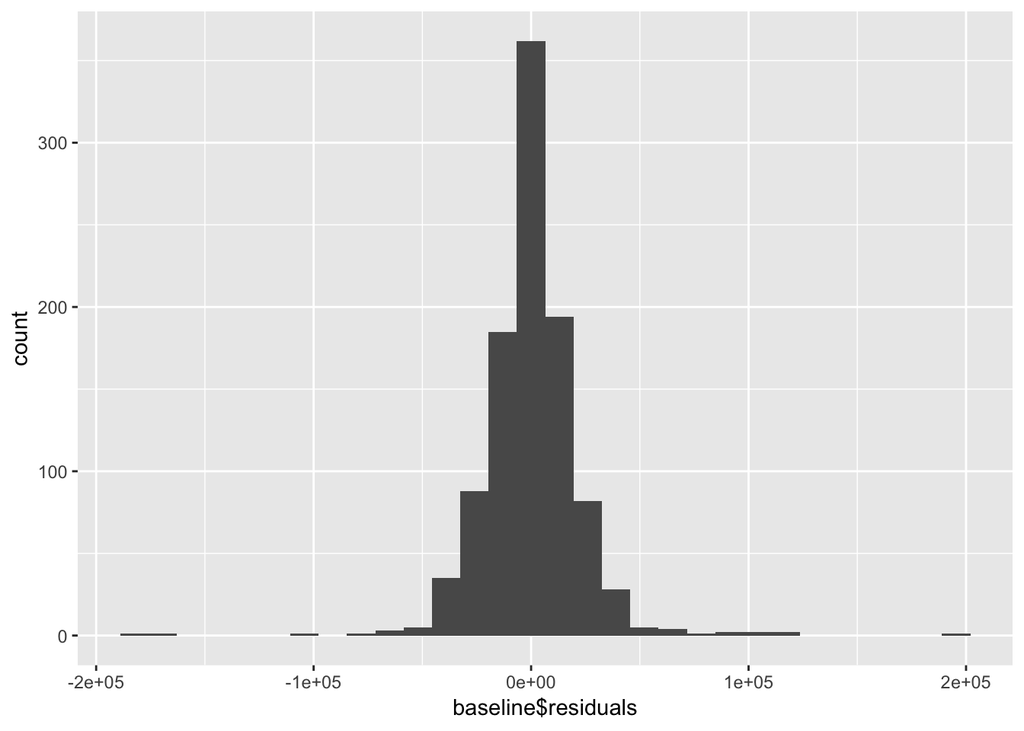

```r
ggplot(mapping=aes(x=baseline$residuals)) + geom_histogram()
```

```r
print(mean(baseline$residuals))
```

```
## [1] -8.715603e-13
```

```r
print(sd(baseline$residuals))
```

```
## [1] 22353.75
```

```r
print(mean(baseline$residuals^2))
```

```
## [1] 499191724
```

```r
#print(mean((predict(baseline, test_smp) - test_smp$SalePrice)^2))
```

Se observa lo siguiente: - Los errores se distribuyen de manera Normal con media cero. - La R2 presenta un valor de 0.92 (cercano a 1 lo que indica que el modelo parece ajustar bien). - La R2 ajustada presenta un valor de 0.85 (es un valor igualmente alto). - El p-value muestra un valor cercano a cero.

2. MODELO 2. La segunda corrida del modelo se reaizará con ayuda del Stepwise para definir las variables más relevantes para el modelo:

```r
#Stepwise
step <- stepAIC(baseline, direction="both",trace=FALSE)
print(summary(step))
```

```
##
## Call:
## lm(formula = SalePrice ~ LotArea + LotShape + LandContour + LotConfig +
##     LandSlope + Neighborhood + Condition1 + BldgType + HouseStyle +
##     MasVnrArea + ExterQual + BsmtQual + BsmtExposure + BsmtFinType1 +
##     BsmtFinSF1 + HeatingQC + X1stFlrSF + X2ndFlrSF + BsmtFullBath +
##     FullBath + HalfBath + BedroomAbvGr + KitchenAbvGr + KitchenQual +
##     TotRmsAbvGrd + Functional + Fireplaces + GarageCars + GarageQual +
##     GarageCond + WoodDeckSF + X3SsnPorch + ScreenPorch + PoolArea +
##     SaleCondition, data = train_smp)
##
## Residuals:
##     Min      1Q  Median      3Q     Max
## -253689  -13077    -228   11759  214542
##
## Coefficients:
##                        Estimate Std. Error t value Pr(>|t|)
## (Intercept)           1.188e+05  3.287e+04   3.615 0.000318 ***
## LotArea               5.790e-01  1.296e-01   4.470 8.85e-06 ***
## LotShapeIR2           8.692e+03  5.895e+03   1.475 0.140686
## LotShapeIR3          -1.565e+04  1.115e+04  -1.404 0.160773
## LotShapeReg           5.793e+03  2.386e+03   2.428 0.015383 *
## LandContourHLS        2.900e+04  7.898e+03   3.673 0.000254 ***
## LandContourLow        1.135e+04  9.495e+03   1.196 0.232206
## LandContourLvl        2.327e+04  6.111e+03   3.809 0.000149 ***
## LotConfigCulDSac      1.351e+04  4.500e+03   3.003 0.002747 **
## LotConfigFR2         -1.601e+04  5.699e+03  -2.809 0.005083 **
## LotConfigFR3         -1.323e+04  2.128e+04  -0.622 0.534142
## LotConfigInside      -8.621e+02  2.567e+03  -0.336 0.737051
## LandSlopeMod          4.479e+03  5.966e+03   0.751 0.453012
## LandSlopeSev         -3.153e+04  1.439e+04  -2.191 0.028688 *
## NeighborhoodBlueste   1.110e+04  2.322e+04   0.478 0.632667
## NeighborhoodBrDale    9.241e+03  1.531e+04   0.603 0.546391
## NeighborhoodBrkSide   1.433e+03  1.234e+04   0.116 0.907597
## NeighborhoodClearCr   3.710e+03  1.255e+04   0.296 0.767674
## NeighborhoodCollgCr   4.831e+03  1.028e+04   0.470 0.638446
## NeighborhoodCrawfor   3.227e+04  1.181e+04   2.731 0.006434 **
## NeighborhoodEdwards  -2.712e+04  1.110e+04  -2.443 0.014777 *
## NeighborhoodGilbert   1.324e+03  1.108e+04   0.120 0.904886
## NeighborhoodIDOTRR   -1.815e+04  1.294e+04  -1.402 0.161150
```

[output cut: 81 more lines]

```
## WoodDeckSF            2.194e+01  8.085e+00   2.713 0.006786 **
## X3SsnPorch            4.455e+01  3.004e+01   1.483 0.138440
## ScreenPorch           4.807e+01  1.693e+01   2.839 0.004628 **
## PoolArea             -1.167e+02  2.844e+01  -4.103 4.45e-05 ***
## SaleConditionAdjLand  2.247e+04  3.059e+04   0.734 0.462906
## SaleConditionAlloca   1.744e+04  1.530e+04   1.140 0.254450
## SaleConditionFamily   7.384e+03  9.186e+03   0.804 0.421729
## SaleConditionNormal   1.224e+04  4.223e+03   2.898 0.003854 **
## SaleConditionPartial  2.080e+04  5.581e+03   3.728 0.000205 ***
## ---
## Signif. codes:  0 '***' 0.001 '**' 0.01 '*' 0.05 '.' 0.1 ' ' 1
##
## Residual standard error: 29020 on 890 degrees of freedom
## Multiple R-squared:  0.8815, Adjusted R-squared:  0.8666
## F-statistic: 59.14 on 112 and 890 DF,  p-value: < 2.2e-16
```

```r
#cv.lm(df=train2, fit, m=5)
#step <- stepAIC(fit, direction="both")
```

Se observa lo siguiente: - El modelo dejó afuera aquellas variables cuyo p-value es muy alto ya que no contribuyen y seleccionó aquellas que generan valor al modelo. - La R2 presenta un valor de 0.88 y aunque es un poco más baja que en la corrida anterior, la R2 ajustada presenta un valor mejor de 0.86 - El p-value muestra un valor cercano a cero, lo que indica que al menos uno de los predictores introducidos en el modelo está relacionado con la variable respuesta. - El estadístico F tiene un mejor performance en esta corrida.

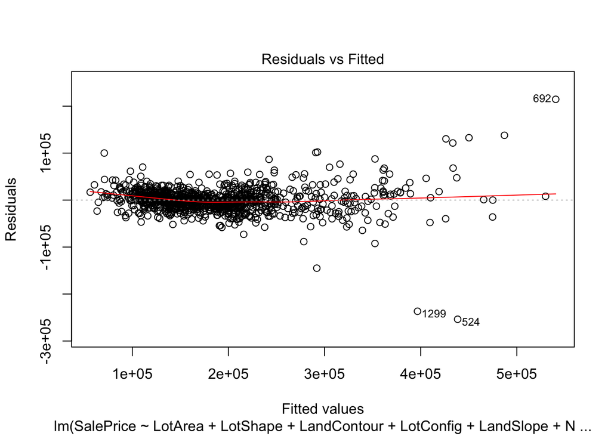

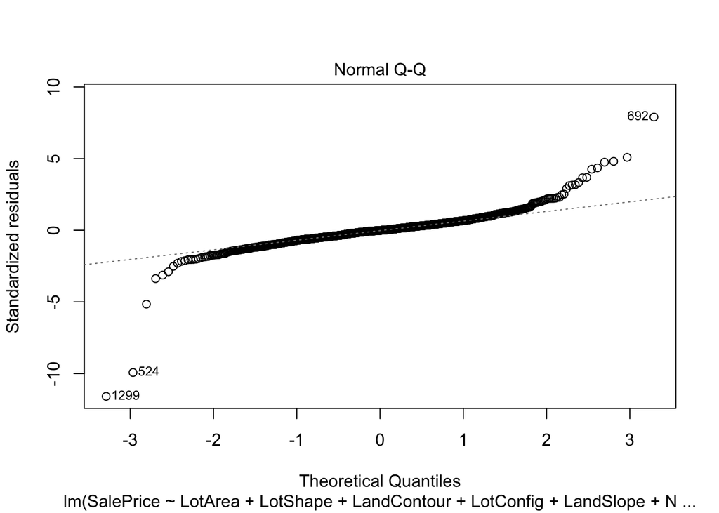

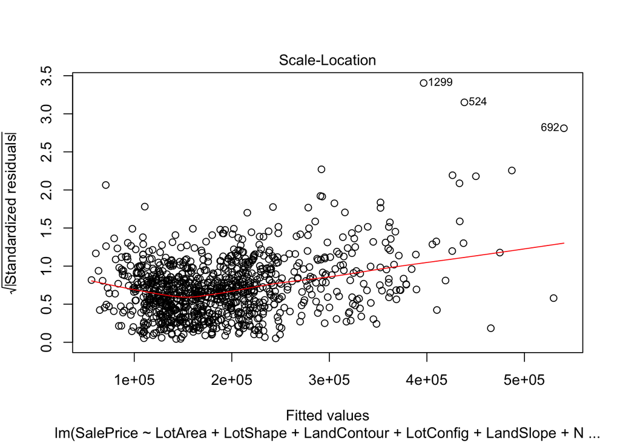

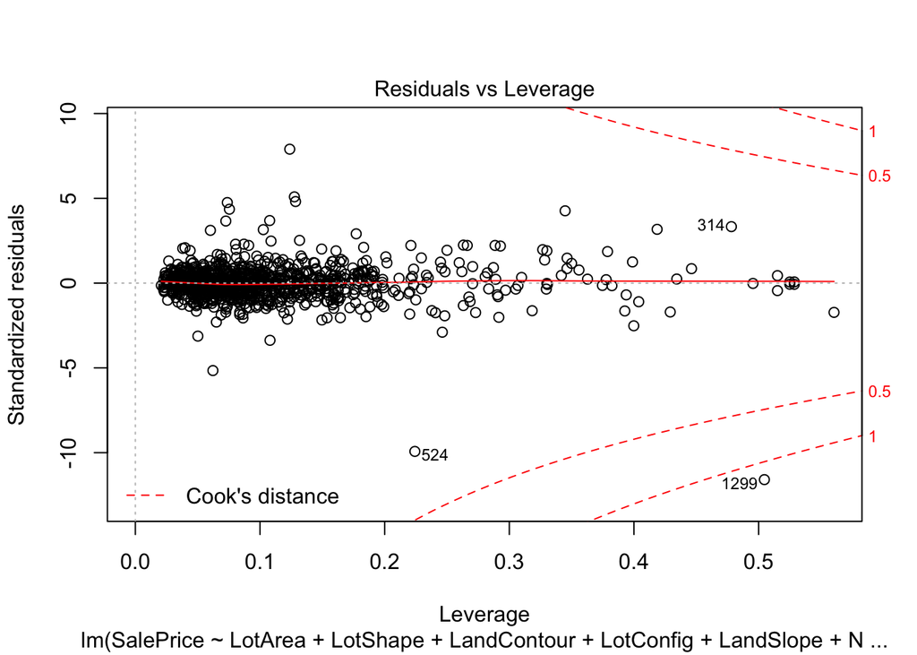

```r
plot(step)
```

Se observa que los resiudales ajustan de manera lineal pero se observan valores atípicos que podrían afectar el performance del modelo.

3. MODELO 3. La tercera corrida del modelo se hará mediante una regresión Ridge

```r
library(glmnet)
```

```r
excluye <- c("SalePrice")

train_x <- data.matrix(train_smp[, !(names(train_smp) %in% excluye)])
test_y <- data.matrix(test_smp)
test_y2 <- data.matrix(test_smp[,"SalePrice"])

lambdas <- 1:150

ridge <- glmnet(train_x, train_smp$SalePrice, alpha=0, lambda=lambdas)

cv_fit <- cv.glmnet(train_x, train_smp$SalePrice, alpha = 0, lambda = lambdas)

#plot(cv_fit)

opt_lambda <- cv_fit$lambda.min
opt_lambda
```

```
## [1] 150
```

```r
fit <- cv_fit$glmnet.fit
summary(fit)
```

```
##           Length Class     Mode
## a0         150   -none-    numeric
## beta      9750   dgCMatrix S4
## df         150   -none-    numeric
## dim          2   -none-    numeric
## lambda     150   -none-    numeric
## dev.ratio  150   -none-    numeric
## nulldev      1   -none-    numeric
## npasses      1   -none-    numeric
## jerr         1   -none-    numeric
## offset       1   -none-    logical
## call         5   -none-    call
## nobs         1   -none-    numeric
```

```r
y_predicted <- predict(fit, s = opt_lambda, newx = train_x)

# Sum of Squares Total and Error
sst <- sum((train_smp$SalePrice - mean(train_smp$SalePrice))^2)
sse <- sum((y_predicted - train_smp$SalePrice)^2)

# R squared
rsq <- 1 - sse / sst
print(rsq)
```

```
## [1] 0.8215424
```

```r
print(sse)
```

```
## [1] 1.129154e+12
```

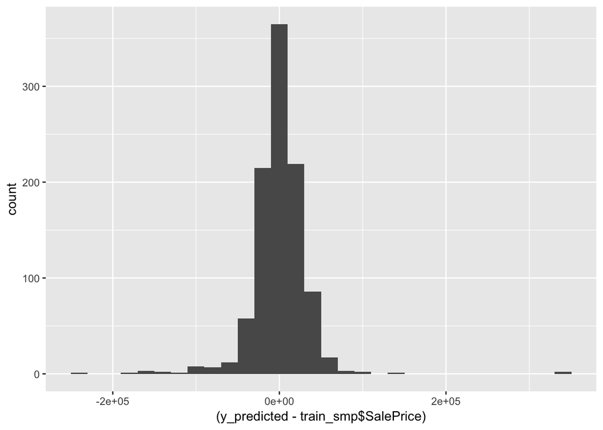

```r
ggplot(mapping=aes(x=(y_predicted - train_smp$SalePrice))) + geom_histogram()
```

4. MODELO 4. La cuarta corrida del modelo se hará mediante una regresión Lasso

```r
lambdas <- 1:75/100

lasso <- glmnet(train_x, train_smp$SalePrice, alpha=1, lambda=lambdas)
print(summary(lasso))
```

```
##           Length Class     Mode
## a0          75   -none-    numeric
## beta      4875   dgCMatrix S4
## df          75   -none-    numeric
## dim          2   -none-    numeric
## lambda      75   -none-    numeric
## dev.ratio   75   -none-    numeric
## nulldev      1   -none-    numeric
## npasses      1   -none-    numeric
## jerr         1   -none-    numeric
## offset       1   -none-    logical
## call         5   -none-    call
## nobs         1   -none-    numeric
```

```r
cv_fit2 <- cv.glmnet(train_x, train_smp$SalePrice, alpha = 1, lambda = lambdas)

#plot(cv_fit)

opt_lambda2 <- cv_fit2$lambda.min
opt_lambda2
```

```
## [1] 0.66
```

```r
fit2 <- cv_fit2$glmnet.fit
summary(fit2)
```

```
##           Length Class     Mode
## a0          75   -none-    numeric
## beta      4875   dgCMatrix S4
## df          75   -none-    numeric
## dim          2   -none-    numeric
## lambda      75   -none-    numeric
## dev.ratio   75   -none-    numeric
## nulldev      1   -none-    numeric
## npasses      1   -none-    numeric
## jerr         1   -none-    numeric
## offset       1   -none-    logical
## call         5   -none-    call
## nobs         1   -none-    numeric
```

```r
y_predicted2 <- predict(fit2, s = opt_lambda2, newx = train_x)

# Sum of Squares Total and Error
sst2 <- sum((train_smp$SalePrice - mean(train_smp$SalePrice))^2)
sse2 <- sum((y_predicted2 - train_smp$SalePrice)^2)

# R squared
rsq2 <- 1 - sse2 / sst2
print(rsq2)
```

```
## [1] 0.8215434
```

```r
print(sse2)
```

```
## [1] 1.129148e+12
```

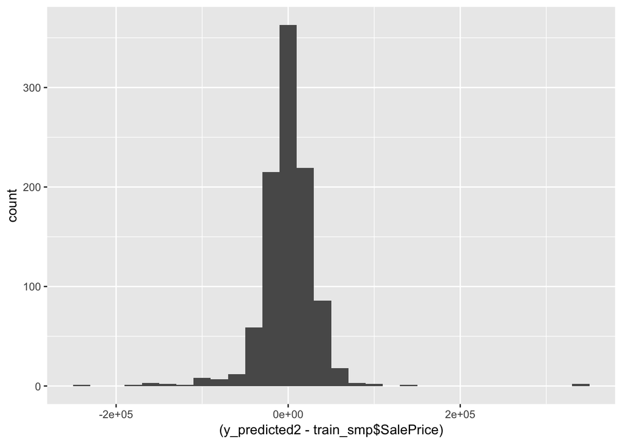

```r
ggplot(mapping=aes(x=(y_predicted2 - train_smp$SalePrice))) + geom_histogram()
```

```r
bc <- boxcox(mpg~weight, data=Auto)
```

[figure not shown]

```r
lambda <- bc$x[bc$y == max(bc$y)]
mod.lin <- lm(((mpg^lambda-1)/lambda)^(1/lambda)~weight, Auto)

print(summary(mod.lin))
```

```
##
## Call:
## lm(formula = ((mpg^lambda - 1)/lambda)^(1/lambda) ~ weight, data = Auto)
##
## Residuals:
##       Min        1Q    Median        3Q       Max
## -0.042338 -0.009074 -0.000718  0.007954  0.069501
##
## Coefficients:
##              Estimate Std. Error t value Pr(>|t|)
## (Intercept) 6.349e-02  2.656e-03   23.90   <2e-16 ***
## weight      3.170e-05  8.579e-07   36.95   <2e-16 ***
## ---
## Signif. codes:  0 '***' 0.001 '**' 0.01 '*' 0.05 '.' 0.1 ' ' 1
##
## Residual standard error: 0.01441 on 390 degrees of freedom
## Multiple R-squared:  0.7778, Adjusted R-squared:  0.7773
## F-statistic:  1365 on 1 and 390 DF,  p-value: < 2.2e-16
```

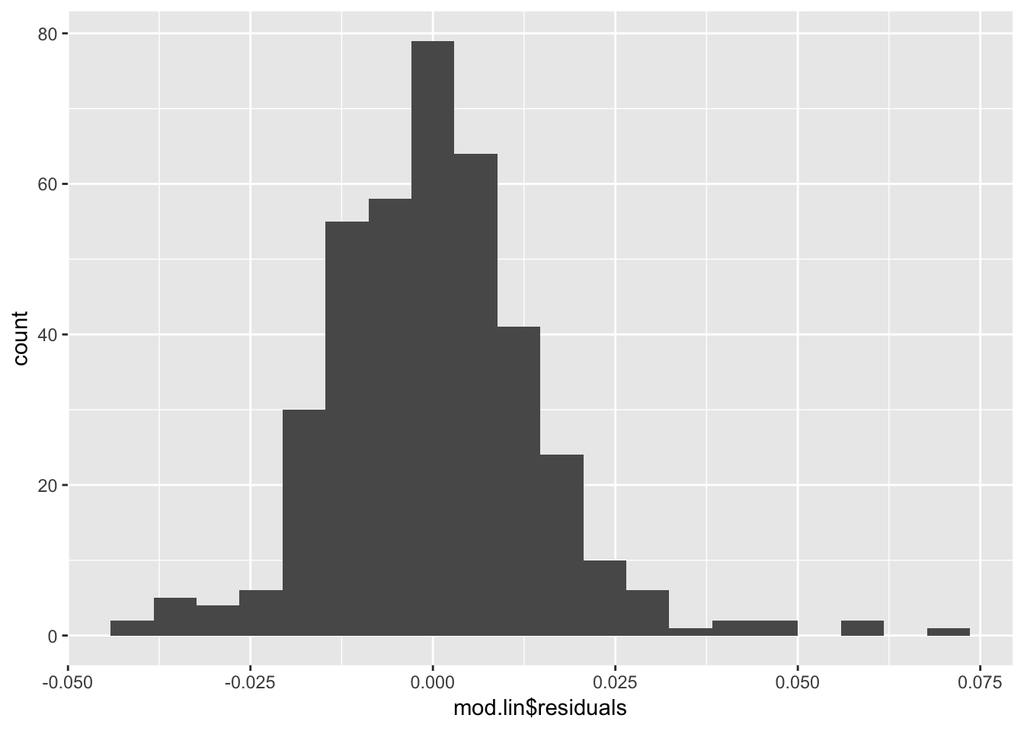

```r
ggplot(mapping=aes(x=mod.lin$residuals)) + geom_histogram(bins=20)
```

```r
print(mean(mod.lin$residuals))
```

```
## [1] 5.254772e-18
```

```r
print(sd(mod.lin$residuals))
```

```
## [1] 0.01439144
```

[figure not shown]

```r
ggplot(Auto, (aes(x=mpg, y=mod.lin$residuals))) + geom_point()
```

[figure not shown]

```r
ggplot(Auto, aes(x=displacement, y=mpg, group=as.factor(cylinders), color=as.factor(cylinders))) +
  geom_point() +
  geom_smooth(method=lm, se=F)
```

El modelo 2 es el que mejor ajusta, se aplicará el mismo a la base Test para medir su presición.

```r
pred <- (predict(object = step, newdata = test_smp))
pred2 <- cbind(p=as.data.frame(pred))
pred2 <- cbind(Id = rownames(pred2),pred2)
rownames(pred2)<- 1:nrow(pred2)


basenew <- merge(x = test_smp, y = pred2, by = "Id", all.x = TRUE)

# Sum of Squares Total and Error
sst <- sum((basenew$SalePrice - mean(basenew$SalePrice))^2)
sse <- sum((basenew$SalePrice - basenew$pred)^2)

# R squared
rsq <- 1 - sse / sst
print(rsq)
```

```
## [1] 0.801375
```

```r
print(sse)
```

```
## [1] 392865144922
```

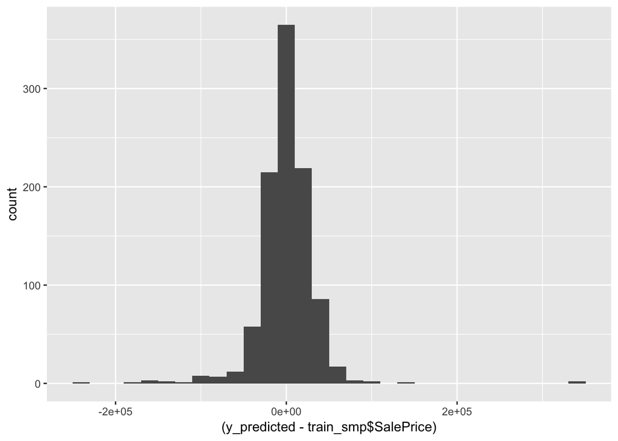

```r
ggplot(mapping=aes(x=(y_predicted - train_smp$SalePrice))) + geom_histogram()
```

Se observa que la R2 también ajusta correctamente por lo cuál este será el modelo elegido para este ejercicio y se aplicará a la base a evaluar.

```r
test[,'Id']<-as.factor(test[,'Id'])
test[,'MSSubClass']<-as.factor(test[,'MSSubClass'])
test[,'OverallQual']<-as.factor(test[,'OverallQual'])
test[,'YearBuilt']<-as.factor(test[,'YearBuilt'])
test[,'YearRemodAdd']<-as.factor(test[,'YearRemodAdd'])
test[,'GarageYrBlt']<-as.factor(test[,'GarageYrBlt'])
test[,'MoSold']<-as.factor(test[,'MoSold'])
test[,'YrSold']<-as.factor(test[,'YrSold'])


test <- test[,!colnames(test)=="Alley"]
test <- test[,!colnames(test)=="Fence"]
test <- test[,!colnames(test)=="MiscFeature"]
test <- test[,!colnames(test)=="PoolQC"]
test <- test[,!colnames(test)=="FireplaceQu"]
test <- test[,!colnames(test)=="LotFrontage"]
test <- test[,!colnames(test)=="Street"]
test <- test[,!colnames(test)=="Utilities"]
test <- test[,!colnames(test)=="Condition2"]
test <- test[,!colnames(test)=="RoofMatl"]
test <- test[,!colnames(test)=="OverallQual"]

pred_final <- (predict(object = step, newdata = test))
pred_final2 <- cbind(p=as.data.frame(pred_final))
pred_final2 <- cbind(Id = rownames(pred_final2),pred_final2)
rownames(pred_final2)<- 1:nrow(pred_final2)

write.csv(pred_final2, file="Pred_Final.csv")
```